# Preprocessing

# Quality Control

The raw data in the primary form contains spot barcodes. Each spot typically contains several cells (1-10 cells per spot on average). Also, the Count depth and the number of genes are not identical between the different spots. As the first step of the Preprocessing, QC is based on those two characteristics, that should be examined simultaneously.

1. Count depth (number of counts per spot)
2. Number of genes per spot

This dashboard allows the user to visualize the data with 3 different plot options:

1. Violin plots displaying the distributions of the count depths and number of genes over the spots
2. A Scatterplot displaying the correlation between the count depth and the number of gens
3. A Spatial plot visualizing the count depth of each spot in the tissue.

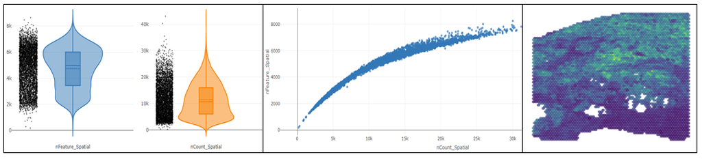

The plots are dynamic, allowing the user to select specific spots and see the information they include. Based on the results, the user can filter out spots based on the minimum and/or maximum count depth or number of genes they include. The filtering is threshold-based.

After the normalization, the user can re-create the above-mentioned plots displaying the count depth and number of genes distributions across the spots.

# Normalization and Primary Feature Selection

Count depths for identical cells may differ due to inherent variability during the experiment. This in turn appears in spots. Moreover, the datasets display a mean-variance relationship. To allow for fair comparisons, we first need to transform the data to mitigate the artefact variability. Also, variance stabilization will reduce the mean-variance relationship and the outliers’ effects. The same also holds for the gene counts. The methods can be distinguished in the following categories:

1. Scaling (all genes by a common factor). Most accurate for datasets with various cell types with non-identical cell properties.
2. Regression models. More helpful when the variability across spots may have biological reading.

This dashboard allows the user to select one methodology of each: log-normalization for the former and SCTransform for the latter. SCTransform normalizes the data using negative binomial regression.

Both options mitigate the mean-variance relationship and reduce the skewness, therefore making the data not only comparable, but also more appropriate for models/tests based on the normal distribution. After the normalization, the user can create Violin plots displaying the normalized counts distributions.

Additionally, the datasets contain up to 25,000 genes, many of them being non-informative while others may display zero counts. To this end, a primary feature selection of the highly variable genes is beneficial. During SCTransform, this is achieved through statistical tests. Regarding the log-normalization, the user can select a threshold-based number of highly variable genes to filter in. In this case, the criteria available are:

1. Vst: Local polynomial regression between the log-variance and log-mean. Then standardizes the feature values using the observed mean and expected variance (given by the fitted line). Feature variance is then calculated on the standardized values.
2. Mean.var.plot: For each feature, the average expression and dispersion are derived. The features are distinguished in bins based on their average expression. Within each bin, the dispersion z-scores are derived.
3. dispersion: Simply selects the genes with the highest dispersion values.

After the normalization and feature selection, the user can create the plot visualizing the mean-variance relationship of the normalized values.

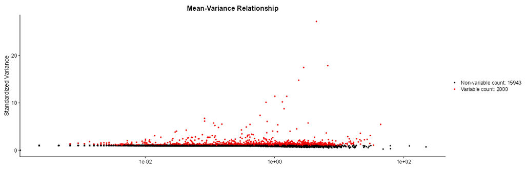

# Dimensionality Reduction

The biological manifold on which cellular expression profiles lie can be sufficiently described by far fewer dimensions than the number of genes. The reduced dimensions are (non-)linear combinations of the original features. There are two main objectives: visualization and summarisation. In this context, the dashboard allows the user to select between several methods (PCA, UMAP, t-SNE) to implement. Afterwards, they can also create an Elbow plot displaying the variance explained within each principal component. Based on that, they can further reduce the dimensionality of their data.

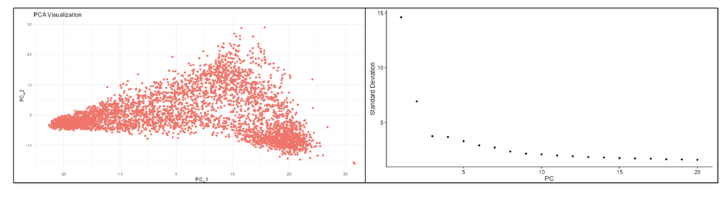